# R Markdown Demo

Professor Becca Selden

6/10/2020

## Objective

To get more familiar with R, Rmarkdown, and the tidyverse

## Initial Setup

The top portion of this is the metadata. Fill this out everytime! Give it a title, you are the author, include the date, and choose the output. Here I choose the html output, using a special theme “flatly” and include a floating table of contents (toc) that automatically generates based on the headers I provide below.

```r
knitr::opts_chunk$set(
  echo = TRUE,
  comment= NA,
  warning = FALSE,
  fig.path=here::here("Rmd.Figures/"))
```

This first time, I’m saying include=TRUE for this to be included in the RMarkdown. In future RMarkdown files, I’ll say include=F to supress this from being shown in RMarkdown.

I also name my chunk “setup”. This both helps with debuging if something fails, and can also be used to automatically name figures based on their code chunk (see below)

Here I also specify the options for how the Markdown should be “knit”.  
- echo=TRUE unless othewise specified, show the RCode that made something  
- comment=NA remove the hash marks that would otherwise show up in the left hand side of the code output  
- warning=FALSE don’t show any warnings that result from running any code  
- fig.path=“place_for_Figures” this will save figures that were generated while rendering the html. They will be named based on the name of the chunk.

## Packages

Since R is open source many people have developed packages to accomplish specific tasks or analyses. We will take advantage of that by installing them.

```r
install.packages("here")
install.packages("tidyverse")
```

Once you have installed a package you don’t have re-run that (so I put eval=F).

When we want to use a package we use the function `library(packagename)`.

```r
library(here)
library(tidyverse)
```

Sometimes two packages have the same name for a function. Whichever one is loaded second will supersede the first, and you will be warned when you load the second package that it is “masking” a function. However, we can specify which one we want to use using `package_name::function_name`.

You can see that `dplyr` within the tidyverse package has a function called `filter()` as does the `stats` package within baseR. If we want to use `filter()` from the stats packages you can say `stats::filter()`

```r
?cars
summary(cars)
```

```
     speed           dist
 Min.   : 4.0   Min.   :  2.00
 1st Qu.:12.0   1st Qu.: 26.00
 Median :15.0   Median : 36.00
 Mean   :15.4   Mean   : 42.98
 3rd Qu.:19.0   3rd Qu.: 56.00
 Max.   :25.0   Max.   :120.00
```

In this case, we are requesting that R provide summary statistics for a built in dataset `cars` using the function `summary()`

Let’s take a look at the `chickwts` dataset that comes with baseR

```r
?chickwts
?plot
```

```
Help on topic 'plot' was found in the following packages:

  Package               Library
  base                  /Library/Frameworks/R.framework/Resources/library
  graphics              /Library/Frameworks/R.framework/Versions/4.3-arm64/Resources/library


Using the first match ...
```

```r
?ggplot

summary(chickwts)
```

```
     weight             feed
 Min.   :108.0   casein   :12
 1st Qu.:204.5   horsebean:10
 Median :258.0   linseed  :12
 Mean   :261.3   meatmeal :11
 3rd Qu.:323.5   soybean  :14
 Max.   :423.0   sunflower:12
```

What are the first few lines of the dataset?

```r
head(chickwts)
```

```
  weight      feed
1    179 horsebean
2    160 horsebean
3    136 horsebean
4    227 horsebean
5    217 horsebean
6    168 horsebean
```

What are the names of the columns?

```r
names(chickwts)
```

```
[1] "weight" "feed"
```

Getting the structure of an object

```r
str(chickwts)
```

```
'data.frame':   71 obs. of  2 variables:
 $ weight: num  179 160 136 227 217 168 108 124 143 140 ...
 $ feed  : Factor w/ 6 levels "casein","horsebean",..: 2 2 2 2 2 2 2 2 2 2 ...
```

We see that the object `chickwts` is a `data.frame` with two variables (columns), and 71 rows (obs.). The column weight is a numeric variable, and feed is a factor with 6 different levels.

## Including Plots

You can also embed plots, and control the dimensions with `fig.width` and `fig.height`. Here I specify the figure will have a width of 5 and a height of 3 inches. Use `fig.cap` to include a figure caption in the html output of the RMarkdown.

For ggplot, you first specify the dataset you want to use for the plot with `ggplot(data)` then specify the geometry you want it to plot in `+geom_something()` where you specify the aesthetics with the argument `aes(x,y)`

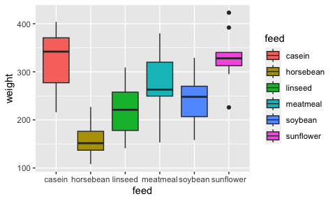

Figure 1. Chick weights on different feed types after 6 weeks

```r
ggplot(data=chickwts) + geom_boxplot(aes(x=feed, y=weight, fill=feed))
```

## Manipulating data

Let’s manipulate the data using the tidyverse

#### Add a column `mutate()`

Create a new column for individual chick ID

```r
chickwts <- chickwts %>%
  mutate(chick_id=seq(1:length(weight)),
         dummy_variable=2+1)
chickwts
```

```
   weight      feed chick_id dummy_variable
1     179 horsebean        1              3
2     160 horsebean        2              3
3     136 horsebean        3              3
4     227 horsebean        4              3
5     217 horsebean        5              3
6     168 horsebean        6              3
7     108 horsebean        7              3
8     124 horsebean        8              3
9     143 horsebean        9              3
10    140 horsebean       10              3
11    309   linseed       11              3
12    229   linseed       12              3
13    181   linseed       13              3
14    141   linseed       14              3
```

[output cut: 57 more lines]

#### Filter data `filter()`

Subset data only to the feed types that are animal based

```r
chickwts_animal <- chickwts %>%
  filter(feed %in% c("casein", "meatmeal"))

chickwts_soy <- chickwts %>%
  filter(feed =="soybean")

#Remove the chickwts_soy
rm(chickwts_soy)
#rm(list=ls()) #remove all things in global environment
```

#### Rename columns

I can change the column name this way

```r
chickwts <- chickwts %>%
  rename(chick_num = chick_id)
```

#### Re-assigning values within a column

I can use `ifelse()` to reclassify values within a column

```r
chickwts <- chickwts %>%
  mutate(size_class=ifelse(weight > 250, "Large", "Small"))
chickwts
```

```
   weight      feed chick_num dummy_variable size_class
1     179 horsebean         1              3      Small
2     160 horsebean         2              3      Small
3     136 horsebean         3              3      Small
4     227 horsebean         4              3      Small
5     217 horsebean         5              3      Small
6     168 horsebean         6              3      Small
7     108 horsebean         7              3      Small
8     124 horsebean         8              3      Small
9     143 horsebean         9              3      Small
10    140 horsebean        10              3      Small
11    309   linseed        11              3      Large
12    229   linseed        12              3      Small
13    181   linseed        13              3      Small
14    141   linseed        14              3      Small
```

[output cut: 57 more lines]

#### Summarize `summarize()` with `group_by()`

```r
chickwts_summ <- chickwts %>%
  group_by(feed) %>%
  summarize(mean_wt=mean(weight), #mean weight on feed type
            sd_wt=sd(weight), #standard deviation of feed type
            n_chicks=n()) #number of chicks raised on each data

chickwts_summ
```

```
# A tibble: 6 × 4
  feed      mean_wt sd_wt n_chicks
  <fct>       <dbl> <dbl>    <int>
1 casein       324.  64.4       12
2 horsebean    160.  38.6       10
3 linseed      219.  52.2       12
4 meatmeal     277.  64.9       11
5 soybean      246.  54.1       14
6 sunflower    329.  48.8       12
```

## Overlaying graphs of data from two datasets

With ggplot we can do this pretty easily by specifying the dataset not in the ggplot call, but in the specific call for the geometry. For example we can plot the raw data from chickwts as points, then overlay the mean and standard deviation from the summary dataset as a point with errorbar.

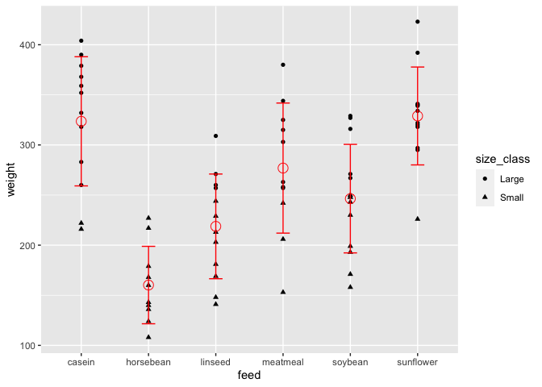

```r
ggplot()+
  geom_point(data=chickwts,
             aes(x=feed, y=weight, pch=size_class))+ #use pch=sizeclass to plot a different symbol for whether the chick is large or small
  geom_point(data=chickwts_summ,
             aes(x=feed, y=mean_wt),
             col="red", pch=1, cex=4)+ #here I specify color is red, type of symbol is pch=1, and make it bigger than the raw data points by expanding it cex=4
  geom_errorbar(data=chickwts_summ,
                aes(x=feed, ymin=mean_wt - sd_wt, ymax=mean_wt+sd_wt),
                width=0.2, col="red") #make it red, and make the width more narrow than the default
```

In this one I also didn’t specify the height or width for the figure in the html. Compare with the first graph

## Merging Data

For this we’ll use the datasets within the tidyverse on a very small subset of rock bandmembers `band_members` and their instruments `band_instruments`

```r
band_members
```

```
# A tibble: 3 × 2
  name  band
  <chr> <chr>
1 Mick  Stones
2 John  Beatles
3 Paul  Beatles
```

```r
band_instruments
```

```
# A tibble: 3 × 2
  name  plays
  <chr> <chr>
1 John  guitar
2 Paul  bass
3 Keith guitar
```

```r
band_instruments2
```

```
# A tibble: 3 × 2
  artist plays
  <chr>  <chr>
1 John   guitar
2 Paul   bass
3 Keith  guitar
```

We can see that `band_members` includes Mick Jagger from the Rolling Stones and two members of the Beatles (John and Paul). We also see that `band_instruments` gives the instrument played by those two Beatles, plus a different member of the Stones. `band_instruments2` has the same data but uses `artist` as the column name rather than `name`

The generic pseudocode for these merges is `new_df <- join(df1, df2)` First, let’s discuss the difference between the types of joins. - `inner_join(df1, df2)` only keeps the rows that are present in both df1 and df2.  
- `left_join(df1, df2)` keeps all the rows in df1 (the L one in the argument), even if they don’t appear in df2, but only keep the ones in df2 that are in df1.  
- `right_join(df1, df2)` keeps all the rows in df2 (the R one in the argument), even if they don’t appear in df1, but only keep the ones in df1 that are in df2.  
- `full_join(df1, df2)` keeps all rows in both df1 and df2.

Let’s try these different types of joins:

```r
inner_join(band_members, band_instruments)
```

```
# A tibble: 2 × 3
  name  band    plays
  <chr> <chr>   <chr>
1 John  Beatles guitar
2 Paul  Beatles bass
```

```r
left_join(band_members, band_instruments)
```

```
# A tibble: 3 × 3
  name  band    plays
  <chr> <chr>   <chr>
1 Mick  Stones  <NA>
2 John  Beatles guitar
3 Paul  Beatles bass
```

```r
right_join(band_members, band_instruments)
```

```
# A tibble: 3 × 3
  name  band    plays
  <chr> <chr>   <chr>
1 John  Beatles guitar
2 Paul  Beatles bass
3 Keith <NA>    guitar
```

```r
full_join(band_members, band_instruments)
```

```
# A tibble: 4 × 3
  name  band    plays
  <chr> <chr>   <chr>
1 Mick  Stones  <NA>
2 John  Beatles guitar
3 Paul  Beatles bass
4 Keith <NA>    guitar
```

How do I merge tables that don’t share a column name? Answer: use the by argument. The one that is kept is the `name`

```r
inner_join(band_members, band_instruments2, by=c("name"="artist"))
```

```
# A tibble: 2 × 3
  name  band    plays
  <chr> <chr>   <chr>
1 John  Beatles guitar
2 Paul  Beatles bass
```